# TA3: IV and the Causal Effect of Local Credit Supply

## Expected Outcomes

By the end of this TA, you should be able to explain:

- why OLS is biased when local demand affects both lending and employment
- what an instrumental variable is and what problem it solves
- what an instrument is trying to do in practice
- how the first stage, reduced form, and 2SLS fit together
- what the exclusion restriction means in this setting
- how to interpret an IV estimate as a causal effect for instrument-induced variation

Download TA3 Code

## The main empirical question

This TA is built around one simple question:

**What is the causal effect of local bank credit supply on county employment growth?**

This maps naturally to the real economy:

- if banks pull back credit supply, local firms may hire less
- if banks expand credit supply, local employment may grow faster

The problem is that observed local credit growth is not pure supply.

### Why OLS is biased

Suppose a county is booming.

- firms want to borrow more
- banks lend more
- employment rises

Then observed credit growth and employment growth move together even if the true causal effect of credit supply is smaller than the raw correlation suggests.

That is the core endogeneity problem:

> **Local demand affects both the regressor and the outcome.**

So OLS does not recover a clean supply effect.

More formally, suppose the object of interest is:

$$employment\_growth_{c,t} = \beta \cdot credit\_supply_{c,t} + u_{c,t}$$

but the variable we actually observe is:

$$observed\_credit\_growth_{c,t} = credit\_supply_{c,t} + demand_{c,t}$$

If `demand` also affects employment growth, then regressing employment growth on observed credit growth mixes:

- the effect of credit supply
- the effect of local demand

That is why the OLS coefficient cannot be interpreted mechanically as causal.

## Endogeneity: the core problem

An endogenous regressor is a regressor that is correlated with the error term in the outcome equation.

In this application, `observed_credit_growth` is endogenous because it reflects both:

- changes in local bank credit supply
- changes in local credit demand

If local demand is omitted from the regression but still affects employment growth, then the regressor is correlated with the omitted component of the outcome equation. That is the precise sense in which OLS is biased.

This is why the issue is not that OLS is “bad” in general. The issue is that OLS needs variation in the regressor that is not contaminated by omitted determinants of the outcome.

## The IV idea in this TA

We use an instrument based on counties’ exposure to banks that were more fragile when a common rate shock hit.

The economic story is:

- some counties are more exposed to fragile banks
- the common rate shock hits fragile banks harder
- those counties experience a worse local credit-supply shock

So the instrument is designed to generate plausibly exogenous variation in local credit growth.

### What an instrumental variable is

An instrumental variable is a variable `Z` that helps us isolate the part of an endogenous regressor `X` that is plausibly unrelated to the omitted confounders in the outcome equation.

In this TA:

- `X` = `observed_credit_growth`
- `Y` = `employment_growth`
- `Z` = `instrument_z`

### When do we use IV?

IV is useful when the regressor of interest is endogenous and we do not trust the identifying variation used by OLS.

Typical reasons a regressor may be endogenous include:

- **omitted variables**: some unobserved factor affects both `X` and `Y`
- **reverse causality**: `Y` may also affect `X`
- **measurement error**: the regressor is measured with error

IV is one way to replace contaminated variation in `X` with a cleaner source of variation coming from `Z`.

So the question is not:

> “Should we use IV because it is more advanced?”

The right question is:

> “Do we have a believable source of exogenous variation that can isolate the part of `X` we care about?”

### What makes a good instrument?

A good instrument is not just something correlated with `X`. It must also be economically interpretable.

In practice, a persuasive instrument usually has:

- a clear economic story for why it moves `X`
- a clear argument for why it does not directly move `Y`
- timing or institutional structure that makes the variation believable
- enough variation to generate a non-trivial first stage

This is why good IV designs are hard to find. The challenge is usually not running 2SLS. The challenge is defending the instrument.

An ideal instrument must satisfy two conditions:

#### 1. Relevance

The instrument must move the endogenous regressor.

Here that means:

> Counties with greater exposure to fragile banks should experience different local credit growth when the common rate shock hits.

#### 2. Exclusion

The instrument should affect the outcome only through the endogenous regressor.

Here that means:

> Exposure to fragile banks should affect county employment growth only because it changes local credit supply, not because it directly changes county employment through some other channel.

### What IV is not

It is important to be clear about what IV does **not** do.

IV is not:

- a generic fix for every bad regression
- a way to avoid thinking carefully about economics
- a method that automatically guarantees causality once the first stage is significant

IV only helps if the instrument is both relevant and excludable. If the economic story behind the instrument is weak, 2SLS does not rescue the design.

### Why fixed effects are not enough here

County fixed effects absorb time-invariant county characteristics such as persistent industrial composition or geography. Year fixed effects absorb common aggregate shocks.

But neither of those fully solves the central problem if counties still experience **time-varying local demand shocks**. If a county has an especially strong local boom in a given year, that can still increase both lending and employment at the same time.

So fixed effects help, but they do not by themselves produce a clean credit-supply estimate.

**Interpretation**

The instrument is not “credit growth itself.” It is a source of variation that shifts credit growth for reasons tied to bank fragility rather than county demand.

## IV versus other identification strategies

It is useful to compare IV to the methods we have already seen or will see later:

- **Fixed effects** remove time-invariant omitted variables, but not all time-varying confounders.
- **Event studies** use sharply timed information shocks and price reactions.
- **Difference-in-differences** compares treated and untreated units over time under a parallel-trends assumption.
- **RDD** uses local quasi-random variation around a threshold.
- **IV** uses an outside source of variation that shifts the endogenous regressor.

So IV is not “better” than every other design. It answers a different identification problem. We use it when the key challenge is that the regressor is endogenous, but we have a plausible external shifter.

### What IV is doing conceptually

The IV design breaks into three parts:

1. **First stage**: does the instrument move local credit growth?
2. **Reduced form**: does the instrument move employment growth?
3. **2SLS**: what is the effect of the instrument-induced part of credit growth on employment growth?

This is the order we follow in the code and in the results below.

It is useful to think of IV as a two-step logic:

- first, isolate the part of credit growth that comes from the instrument
- second, ask what that isolated component does to employment growth

So 2SLS does **not** use all variation in credit growth. It uses only the variation in credit growth that is explained by the instrument.

Another way to say this is:

- OLS asks: what happens to `Y` when `X` changes for **any reason**?
- IV asks: what happens to `Y` when `X` changes for the specific reason captured by `Z`?

That is why IV estimates can differ from OLS estimates even when both are statistically precise.

### The three key equations

It is useful to write the design in equation form.

#### OLS equation

$$employment\_growth_{c,t} = \beta \cdot observed\_credit\_growth_{c,t} + \alpha_c + \gamma_t + \varepsilon_{c,t}$$

This is the naive specification. It is biased if `observed_credit_growth` is correlated with `\varepsilon`.

#### First stage

$$observed\_credit\_growth_{c,t} = \pi \cdot instrument\_z_{c,t} + \alpha_c + \gamma_t + \nu_{c,t}$$

This checks whether the instrument moves the endogenous regressor.

#### Reduced form

$$employment\_growth_{c,t} = \rho \cdot instrument\_z_{c,t} + \alpha_c + \gamma_t + \eta_{c,t}$$

This checks whether the instrument also moves the outcome.

#### 2SLS

2SLS combines the first stage and reduced form to estimate the effect of the part of credit growth that is predicted by the instrument.

In many simple settings, it is helpful to think of 2SLS as:

$$\text{2SLS estimate} \approx \frac{\text{reduced form}}{\text{first stage}}$$

This is not just a computational trick. It shows the intuition:

- how much does the instrument move the outcome?
- how much does the instrument move the endogenous regressor?
- the ratio tells us how much the outcome changes per unit of instrument-induced movement in the regressor

This ratio intuition helps explain why the first stage matters so much.

## What is testable and what is not

Some parts of an IV design can be checked directly in the data, and some cannot.

### Things we can partially check

- whether the first stage is strong enough to be meaningful
- whether the sign of the reduced form is economically sensible
- whether results are stable across specifications

### Things we cannot directly prove from the data

- the exclusion restriction

The exclusion restriction is ultimately an economic argument, not a purely statistical result. That is why the interpretation of the instrument matters so much.

## Common mistakes in IV reasoning

Students often make a few predictable mistakes when first learning IV:

### Mistake 1: “A significant first stage proves the instrument is valid.”

No. A significant first stage only helps with **relevance**. It says nothing by itself about **exclusion**.

### Mistake 2: “IV gives the true effect of X on Y.”

Not necessarily. IV gives the effect for the variation in `X` induced by the instrument, not for every possible source of variation in `X`.

### Mistake 3: “If OLS and IV differ, IV must be right.”

Not automatically. The difference may reflect endogeneity, but it could also reflect a weak or invalid instrument. The economic argument still matters.

### Mistake 4: “If fixed effects are included, IV is unnecessary.”

No. Fixed effects and IV solve different problems. Fixed effects absorb some omitted variables; IV replaces the variation in the endogenous regressor with a cleaner source.

### Weak instruments

A weak instrument is an instrument that only weakly moves the endogenous regressor.

Why this matters:

- the first stage becomes noisy
- 2SLS estimates become unstable
- inference becomes less reliable

So a strong first stage is necessary. However, it is **not sufficient**: an instrument can be strong and still fail the exclusion restriction.

## What 2SLS identifies

The 2SLS estimate is not “the effect of all lending on all counties in all circumstances.”

It is the effect of credit growth for the part of lending that is shifted by the instrument. In IV language, this is a **local average treatment effect**.

In this TA, the interpretation is:

> the effect of local credit supply on employment growth for counties whose lending conditions move because they are more exposed to fragile banks when the common rate shock hits.

This is a more precise and more honest interpretation than saying simply “the effect of lending on employment.”

## Time to Code!

We use:

- `code/04_ta3_iv_credit_supply.R`

The script proceeds in the same order as the economic logic:

1. describe the county panel
2. show why OLS is not enough
3. estimate the first stage
4. estimate the reduced form
5. estimate the 2SLS model

```r
iv_model <- fixest::feols(
  employment_growth ~ 1 | county_fips + year | observed_credit_growth ~ instrument_z,
  cluster = ~county_fips,
  data = county_panel
)
```

### Step 1: design summary

This table gives a quick feel for how counties differ depending on whether they have high or low exposure to the instrument.

```r
design_summary <- readr::read_csv("output/tables/ta3_design_summary.csv", show_col_types = FALSE) |>
  dplyr::mutate(dplyr::across(where(is.numeric), ~round(.x, 3)))

knitr::kable(design_summary, caption = "Counties with high and low instrument exposure")
```

Counties with high and low instrument exposure

| exposure_group | mean_observed_credit_growth | mean_county_credit_supply | mean_employment_growth | mean_local_demand |
| --- | --- | --- | --- | --- |
| High instrument exposure | 0.123 | 0.094 | 0.105 | 0.026 |
| Low instrument exposure | 0.151 | 0.095 | 0.144 | 0.097 |

The point of this table is not to prove the design by itself. It is simply to make the instrument concrete before looking at regressions.

### Step 2: naive OLS relationship

Before using IV, look at the raw correlation. This is what OLS is trying to summarize.

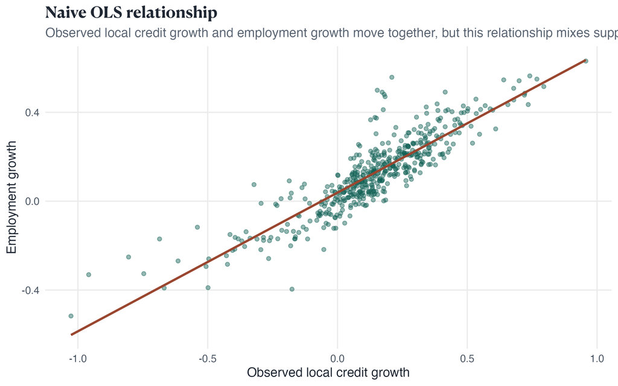

The danger is that this relationship mixes:

- credit supply
- local demand

So it is not automatically causal.

This is the motivation for IV. If local demand pushes both lending and employment upward, the OLS slope will generally be biased.

### Step 3: first stage

Now we ask whether the instrument moves local credit growth in the expected direction.

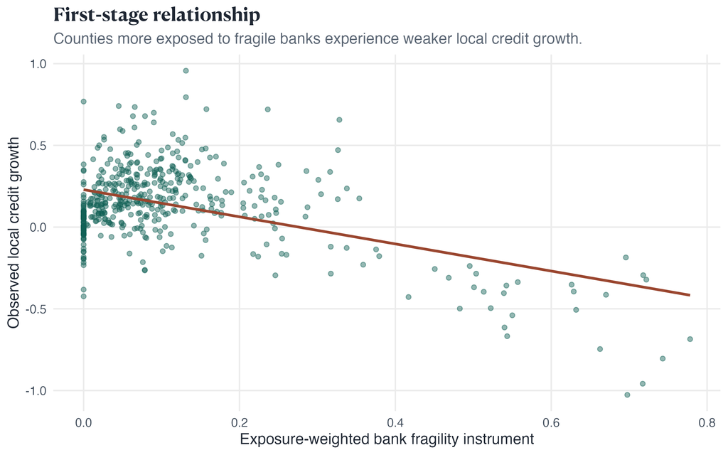

If the first stage is weak, the whole IV design becomes fragile.

In other words, IV only makes sense if the instrument actually shifts the endogenous regressor in a meaningful way.

### Step 4: reduced form

The reduced form asks whether the instrument moves the outcome.

This step is useful because it connects the instrument directly to the economic object of interest:

- if the instrument shifts local credit growth
- and the instrument also shifts employment growth

then 2SLS combines those two relationships into an estimate of the causal effect of local credit supply on employment.

### Step 5: ordered main results

The table below is deliberately ordered exactly as the code creates the results:

1. OLS
2. First stage
3. Reduced form
4. 2SLS

```r
main_results <- readr::read_csv("output/tables/ta3_main_result_summary.csv", show_col_types = FALSE)

knitr::kable(
  main_results |>
    dplyr::select(step, estimand, model_name, estimate, std.error, statistic, p.value),
  caption = "Main TA3 results"
)
```

Main TA3 results

| step | estimand | model_name | estimate | std.error | statistic | p.value |
| --- | --- | --- | --- | --- | --- | --- |
| 1 | Naive correlation between local credit growth and employment growth | OLS | 0.5239 | 0.0535 | 9.7876 | 0.0000 |
| 2 | Effect of the instrument on local credit growth | First stage | -0.9039 | 0.0893 | -10.1262 | 0.0000 |
| 3 | Effect of the instrument on employment growth | Reduced form | -0.0571 | 0.0609 | -0.9380 | 0.3540 |
| 4 | Causal effect of local credit supply on employment growth | 2SLS | 0.0632 | 0.0628 | 1.0065 | 0.3204 |

This table should be read as a sequence, not as four unrelated regressions:

1. **OLS** shows the naive correlation.
2. **First stage** shows whether the instrument moves credit growth.
3. **Reduced form** shows whether the instrument moves employment growth.
4. **2SLS** converts those two pieces into a causal estimate.

### Step 6: full regression output

```r
ta3_models <- readr::read_csv("output/tables/ta3_model_table.csv", show_col_types = FALSE) |>
  dplyr::select(model, term, estimate, std.error, statistic, p.value) |>
  dplyr::mutate(
    model = factor(model, levels = c("OLS", "First stage", "Reduced form", "2SLS"))
  ) |>
  dplyr::arrange(model) |>
  dplyr::mutate(dplyr::across(c(estimate, std.error, statistic, p.value), ~round(.x, 3)))

knitr::kable(ta3_models, caption = "OLS, first-stage, reduced-form, and IV estimates")
```

OLS, first-stage, reduced-form, and IV estimates

| model | term | estimate | std.error | statistic | p.value |
| --- | --- | --- | --- | --- | --- |
| OLS | observed_credit_growth | 0.524 | 0.054 | 9.788 | 0.000 |
| First stage | instrument_z | -0.904 | 0.089 | -10.126 | 0.000 |
| Reduced form | instrument_z | -0.057 | 0.061 | -0.938 | 0.354 |
| 2SLS | fit_observed_credit_growth | 0.063 | 0.063 | 1.007 | 0.320 |

### How to interpret the 2SLS estimate

The 2SLS coefficient should be interpreted as:

> the effect of local credit growth on employment growth for the part of credit growth that is moved by the instrument.

This is not necessarily the effect of **all** lending variation. It is the effect for the variation induced by county exposure to fragile banks hit by the common rate shock.

This is the standard local-average-treatment-effect logic behind IV.

### Step 7: OLS versus 2SLS

This plot is often the easiest way to summarize the lesson:

- OLS uses all observed variation in credit growth
- 2SLS uses only the variation induced by the instrument

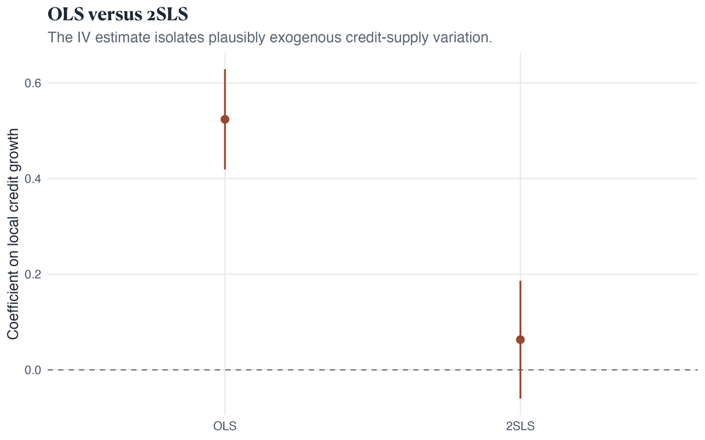

## What to take away from this TA

The main lesson is not “IV is more advanced than OLS.” The main lesson is:

> When the regressor is endogenous, we need a source of variation that moves the regressor for reasons unrelated to the omitted confounders.

In this application:

- OLS is biased because local demand affects both lending and employment
- the instrument shifts local credit growth through bank fragility and the common rate shock
- 2SLS uses that instrument-driven variation to estimate a causal effect